# Fashion Retail Capstone — Classification, Clustering & NLP on Customer Reviews

```python
# --- 7.4 Fit the selected K-Means and profile each cluster ------------------
kmeans = KMeans(n_clusters=best_k, random_state=RANDOM_STATE, n_init=10)
class_profile["cluster"] = kmeans.fit_predict(X_cluster)

cluster_means = class_profile.groupby("cluster")[CLUSTER_FEATURES].mean()
cluster_means.insert(0, "n_classes", class_profile.groupby("cluster").size())
cluster_means["total_reviews"] = class_profile.groupby("cluster")["review_count"].sum()

print("Mean of each aggregate column, per cluster:\n")
display(cluster_means.round(4))

print("\nWhich product classes landed in each cluster:\n")
for c in sorted(class_profile["cluster"].unique()):
    members = class_profile[class_profile["cluster"] == c].sort_values(
        "review_count", ascending=False)
    print(f"Cluster {c}  ({len(members)} classes, "
          f"{int(members['review_count'].sum()):,} reviews)")
    for name, row in members.iterrows():
        print(f"    {name:<22} n={int(row['review_count']):>5,}  "
              f"avg_rating={row['avg_rating']:.2f}  "
              f"recommend_rate={row['recommend_rate']:.3f}  "
              f"avg_sentiment={row['avg_sentiment']:.3f}")
    print()

RESULTS["task7"]["cluster_means"] = {
    str(c): {k: round(float(v), 4) for k, v in row.items()}
    for c, row in cluster_means.to_dict(orient="index").items()
}
RESULTS["task7"]["cluster_members"] = {
    str(c): sorted(class_profile[class_profile["cluster"] == c].index.tolist())
    for c in sorted(class_profile["cluster"].unique())
}
```

```
Mean of each aggregate column, per cluster:
```

| cluster | n_classes | avg_rating | recommend_rate | review_count | avg_sentiment | avg_age | total_reviews |
| --- | --- | --- | --- | --- | --- | --- | --- |
| 0 | 18 | 4.2154 | 0.8304 | 1257.0 | 0.2481 | 42.7871 | 22626 |
| 1 | 2 | 4.0000 | 1.0000 | 1.0 | 0.4650 | 32.0000 | 2 |

```
Which product classes landed in each cluster:

Cluster 0  (18 classes, 22,626 reviews)
    Dresses                n=6,145  avg_rating=4.14  recommend_rate=0.805  avg_sentiment=0.250
    Knits                  n=4,626  avg_rating=4.15  recommend_rate=0.812  avg_sentiment=0.251
    Blouses                n=2,983  avg_rating=4.14  recommend_rate=0.807  avg_sentiment=0.253
    Sweaters               n=1,380  avg_rating=4.17  recommend_rate=0.797  avg_sentiment=0.245
    Pants                  n=1,350  avg_rating=4.26  recommend_rate=0.833  avg_sentiment=0.245
    Jeans                  n=1,104  avg_rating=4.35  recommend_rate=0.880  avg_sentiment=0.251
    Fine gauge             n=1,059  avg_rating=4.24  recommend_rate=0.833  avg_sentiment=0.246
    Skirts                 n=  903  avg_rating=4.23  recommend_rate=0.842  avg_sentiment=0.258
    Jackets                n=  683  avg_rating=4.29  recommend_rate=0.843  avg_sentiment=0.245
    Lounge                 n=  669  avg_rating=4.30  recommend_rate=0.858  avg_sentiment=0.245
    Swim                   n=  332  avg_rating=4.17  recommend_rate=0.795  avg_sentiment=0.267
    Outerwear              n=  319  avg_rating=4.18  recommend_rate=0.812  avg_sentiment=0.226
    Shorts                 n=  304  avg_rating=4.25  recommend_rate=0.839  avg_sentiment=0.248
    Sleep                  n=  214  avg_rating=4.29  recommend_rate=0.855  avg_sentiment=0.254
    Legwear                n=  158  avg_rating=4.25  recommend_rate=0.854  avg_sentiment=0.260
    Intimates              n=  147  avg_rating=4.28  recommend_rate=0.857  avg_sentiment=0.264
    Layering               n=  132  avg_rating=4.35  recommend_rate=0.879  avg_sentiment=0.256
    Trend                  n=  118  avg_rating=3.84  recommend_rate=0.746  avg_sentiment=0.202

Cluster 1  (2 classes, 2 reviews)
    Casual bottoms         n=    1  avg_rating=4.00  recommend_rate=1.000  avg_sentiment=0.330
    Chemises               n=    1  avg_rating=4.00  recommend_rate=1.000  avg_sentiment=0.600
```

```
saved -> docs/figures/task7_cluster_profiles.png
```

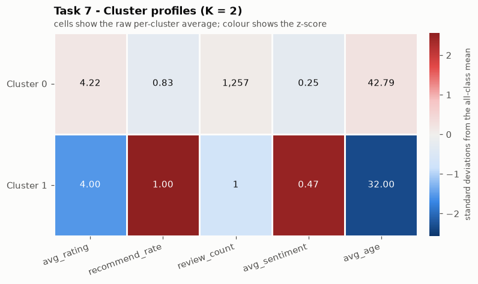

```python
# --- 7.5 Chart: cluster profile heatmap (z-scores) --------------------------
# Diverging blue<->red with a neutral grey midpoint: the values are signed
# deviations from the corpus average, so zero has to read as "nothing".
z_profile = pd.DataFrame(
    cluster_scaler.transform(cluster_means[CLUSTER_FEATURES]),
    index=[f"Cluster {c}" for c in cluster_means.index],
    columns=CLUSTER_FEATURES,
)

diverging = mpl.colors.LinearSegmentedColormap.from_list(
    "blue_grey_red", ["#0d366b", "#3987e5", "#cde2fb", "#f0efec",
                      "#f6c4c4", "#e34948", "#8f2020"])
vmax = float(np.abs(z_profile.to_numpy()).max())

fig, ax = plt.subplots(figsize=(7.6, 0.9 * len(z_profile) + 2.2))
im = ax.imshow(z_profile.to_numpy(), cmap=diverging, vmin=-vmax, vmax=vmax, aspect="auto")

ax.set_xticks(range(len(CLUSTER_FEATURES)))
ax.set_xticklabels(CLUSTER_FEATURES, rotation=20, ha="right")
ax.set_yticks(range(len(z_profile)))
ax.set_yticklabels(z_profile.index)

# Every cell is directly labelled with its raw value - the colour is a secondary cue.
for i in range(z_profile.shape[0]):
    for j, col in enumerate(CLUSTER_FEATURES):
        z = z_profile.iat[i, j]
        raw = cluster_means[col].iloc[i]
        txt = f"{raw:,.0f}" if col == "review_count" else f"{raw:.2f}"
        ax.text(j, i, txt, ha="center", va="center", fontsize=9.5,
                color="#ffffff" if abs(z) > vmax * 0.55 else "#0b0b0b")

ax.set_xticks(np.arange(-.5, len(CLUSTER_FEATURES), 1), minor=True)
ax.set_yticks(np.arange(-.5, len(z_profile), 1), minor=True)
ax.grid(which="minor", color="#fcfcfb", linewidth=2)
ax.tick_params(which="minor", length=0)
for s in ax.spines.values():
    s.set_visible(False)

cbar = fig.colorbar(im, ax=ax, fraction=0.035, pad=0.03)
cbar.set_label("standard deviations from the all-class mean", fontsize=8.5, color="#52514e")
cbar.outline.set_visible(False)

ax.set_title(f"Task 7 - Cluster profiles (K = {best_k})", loc="left", pad=20)
ax.text(0.0, 1.02, "cells show the raw per-cluster average; colour shows the z-score",
        transform=ax.transAxes, fontsize=9, color="#52514e", ha="left", va="bottom")
save_fig(fig, "task7_cluster_profiles")
plt.show()
```

### 7.6 Robustness check — the same rule, minus the two singleton classes

The required rule is not wrong, but its answer is **degenerate**. `Casual bottoms` and `Chemises` have **one review each**, which places them far below every other class on `review_count` and makes them trivially separable. K-Means splits off the two outliers, the silhouette score rewards that handsomely (0.626), and the "winning" partition tells merchandising nothing — cluster 0 is simply *the entire assortment*.

So we re-run the **identical** procedure — same 5 aggregate features, same `StandardScaler`, same K = 2..8 silhouette sweep, same `random_state=42`, same `n_init=10` — on classes with at least **30 reviews**. This is the only judgement call in Task 7 and it is stated rather than hidden. It is also insensitive to the exact cut-off: the two singletons are the only classes below 118 reviews, so *any* threshold from 2 to 118 produces exactly the same clusters.

```python
MIN_REVIEWS = 30
robust_profile = class_profile[class_profile["review_count"] >= MIN_REVIEWS].copy()
dropped = sorted(set(class_profile.index) - set(robust_profile.index))

print(f"Classes retained: {len(robust_profile)} of {len(class_profile)} "
      f"(>= {MIN_REVIEWS} reviews)")
print(f"Classes dropped : {dropped} "
      f"({int(class_profile.loc[dropped, 'review_count'].sum())} reviews in total)")

robust_scaler = StandardScaler()
X_robust = robust_scaler.fit_transform(robust_profile[CLUSTER_FEATURES])

robust_sil = []
for k in range(2, 9):
    km = KMeans(n_clusters=k, random_state=RANDOM_STATE, n_init=10)
    robust_sil.append({
        "K": k,
        "silhouette_score": silhouette_score(X_robust, km.fit_predict(X_robust)),
    })
robust_sil = pd.DataFrame(robust_sil).set_index("K").round(4)
robust_k = int(robust_sil["silhouette_score"].idxmax())

print(f"\nSilhouette sweep on the {len(robust_profile)} retained classes:\n")
display(robust_sil)
print(f"Selected K = {robust_k} "
      f"(silhouette {robust_sil.loc[robust_k, 'silhouette_score']:.4f})")
```

```
Classes retained: 18 of 20 (>= 30 reviews)
Classes dropped : ['Casual bottoms', 'Chemises'] (2 reviews in total)

Silhouette sweep on the 18 retained classes:
```

| K | silhouette_score |
| --- | --- |
| 2 | 0.3555 |
| 3 | 0.3051 |
| 4 | 0.3084 |
| 5 | 0.3208 |
| 6 | 0.2412 |
| 7 | 0.2448 |
| 8 | 0.2518 |

```
Selected K = 2 (silhouette 0.3555)
```

```python
robust_km = KMeans(n_clusters=robust_k, random_state=RANDOM_STATE, n_init=10)
robust_profile["cluster"] = robust_km.fit_predict(X_robust)

robust_means = robust_profile.groupby("cluster")[CLUSTER_FEATURES].mean()
robust_means.insert(0, "n_classes", robust_profile.groupby("cluster").size())
robust_means["total_reviews"] = robust_profile.groupby("cluster")["review_count"].sum()

print("Mean of each aggregate column, per merchandising tier:\n")
display(robust_means.round(4))

for c in sorted(robust_profile["cluster"].unique()):
    members = robust_profile[robust_profile["cluster"] == c].sort_values(
        "review_count", ascending=False)
    print(f"Tier {c}  ({len(members)} classes, "
          f"{int(members['review_count'].sum()):,} reviews)")
    for name, row in members.iterrows():
        print(f"    {name:<12} n={int(row['review_count']):>6,}  "
              f"avg_rating={row['avg_rating']:.3f}  "
              f"recommend_rate={row['recommend_rate']:.3f}  "
              f"avg_sentiment={row['avg_sentiment']:.3f}  "
              f"avg_age={row['avg_age']:.1f}")
    print()

RESULTS["task7"]["robust"] = {
    "min_reviews": MIN_REVIEWS,
    "dropped_classes": dropped,
    "n_classes": int(len(robust_profile)),
    "silhouette_table": {int(k): round(float(v), 4)
                         for k, v in robust_sil["silhouette_score"].items()},
    "best_k": robust_k,
    "best_silhouette": round(float(robust_sil.loc[robust_k, "silhouette_score"]), 4),
    "cluster_means": {str(c): {k: round(float(v), 4) for k, v in row.items()}
                      for c, row in robust_means.to_dict(orient="index").items()},
    "cluster_members": {str(c): sorted(robust_profile[robust_profile["cluster"] == c].index.tolist())
                        for c in sorted(robust_profile["cluster"].unique())},
}
robust_profile.to_csv(OUT_DIR / "task7_merchandising_tiers.csv")
```

```
Mean of each aggregate column, per merchandising tier:
```

| cluster | n_classes | avg_rating | recommend_rate | review_count | avg_sentiment | avg_age | total_reviews |
| --- | --- | --- | --- | --- | --- | --- | --- |
| 0 | 12 | 4.2717 | 0.8473 | 587.9167 | 0.2533 | 42.2002 | 7055 |
| 1 | 6 | 4.1028 | 0.7965 | 2595.1667 | 0.2379 | 43.9609 | 15571 |

```
Tier 0  (12 classes, 7,055 reviews)
    Pants        n= 1,350  avg_rating=4.261  recommend_rate=0.833  avg_sentiment=0.245  avg_age=44.2
    Jeans        n= 1,104  avg_rating=4.348  recommend_rate=0.880  avg_sentiment=0.251  avg_age=43.2
    Fine gauge   n= 1,059  avg_rating=4.238  recommend_rate=0.833  avg_sentiment=0.246  avg_age=44.9
    Skirts       n=   903  avg_rating=4.229  recommend_rate=0.842  avg_sentiment=0.258  avg_age=42.6
    Jackets      n=   683  avg_rating=4.288  recommend_rate=0.843  avg_sentiment=0.245  avg_age=44.1
    Lounge       n=   669  avg_rating=4.302  recommend_rate=0.858  avg_sentiment=0.245  avg_age=42.8
    Swim         n=   332  avg_rating=4.172  recommend_rate=0.795  avg_sentiment=0.267  avg_age=38.2
    Shorts       n=   304  avg_rating=4.253  recommend_rate=0.839  avg_sentiment=0.248  avg_age=40.8
    Sleep        n=   214  avg_rating=4.294  recommend_rate=0.855  avg_sentiment=0.254  avg_age=43.2
    Legwear      n=   158  avg_rating=4.247  recommend_rate=0.854  avg_sentiment=0.260  avg_age=41.6
    Intimates    n=   147  avg_rating=4.279  recommend_rate=0.857  avg_sentiment=0.264  avg_age=38.9
    Layering     n=   132  avg_rating=4.348  recommend_rate=0.879  avg_sentiment=0.256  avg_age=42.0

Tier 1  (6 classes, 15,571 reviews)
    Dresses      n= 6,145  avg_rating=4.139  recommend_rate=0.805  avg_sentiment=0.250  avg_age=42.2
    Knits        n= 4,626  avg_rating=4.146  recommend_rate=0.812  avg_sentiment=0.251  avg_age=43.7
    Blouses      n= 2,983  avg_rating=4.143  recommend_rate=0.807  avg_sentiment=0.253  avg_age=44.3
    Sweaters     n= 1,380  avg_rating=4.169  recommend_rate=0.797  avg_sentiment=0.245  avg_age=45.2
    Outerwear    n=   319  avg_rating=4.182  recommend_rate=0.812  avg_sentiment=0.226  avg_age=44.4
    Trend        n=   118  avg_rating=3.839  recommend_rate=0.746  avg_sentiment=0.202  avg_age=44.0
```

```
saved -> docs/figures/task7_merchandising_tiers.png
```

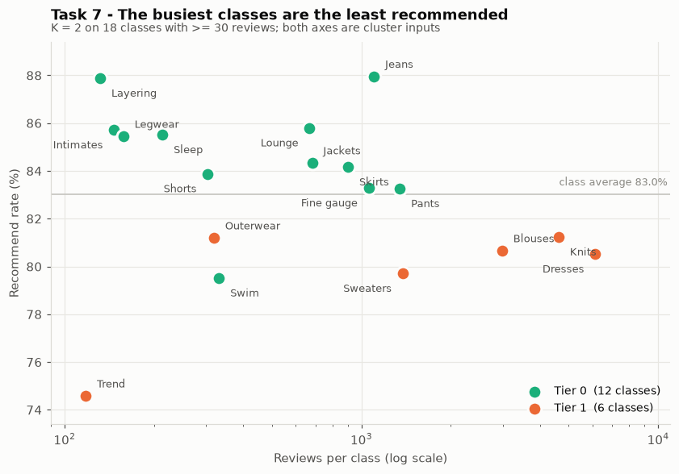

```python
# --- 7.7 Chart: the tiers on their two decisive axes ------------------------
# Volume vs. satisfaction is where the tiers actually separate; both are
# cluster inputs, and one shared value axis carries the comparison.
TIER_COLORS = {0: AQUA, 1: ORANGE}
# Three-way rotation of label placement so neighbouring points never collide.
LABEL_OFFSETS = [(9, 7, "left"), (9, -15, "left"), (-9, -15, "right")]

fig, ax = plt.subplots(figsize=(9.0, 5.6))
# Alternate the label offset by x-rank so neighbouring points never collide.
rank = {name: i for i, name in
        enumerate(robust_profile.sort_values("review_count").index)}
for c in sorted(robust_profile["cluster"].unique()):
    sub = robust_profile[robust_profile["cluster"] == c]
    ax.scatter(sub["review_count"], sub["recommend_rate"] * 100,
               s=120, color=TIER_COLORS[c], edgecolor="#fcfcfb", linewidth=2,
               label=f"Tier {c}  ({len(sub)} classes)", zorder=3)
    # Every point is directly labelled - colour is never the only cue.
    for name, row in sub.iterrows():
        dx, dy, ha = LABEL_OFFSETS[rank[name] % 3]
        ax.annotate(name, (row["review_count"], row["recommend_rate"] * 100),
                    xytext=(dx, dy), textcoords="offset points", ha=ha,
                    fontsize=8.5, color="#52514e")

overall = robust_profile["recommend_rate"].mean() * 100
ax.axhline(overall, color="#c9c8c3", linewidth=1.2, zorder=1)
ax.text(0.995, overall + 0.25, f"class average {overall:.1f}%",
        transform=ax.get_yaxis_transform(), ha="right", va="bottom",
        fontsize=8.5, color="#8a8983")

ax.set_xscale("log")
style_axes(ax, xlabel="Reviews per class (log scale)", ylabel="Recommend rate (%)",
           title="Task 7 - The busiest classes are the least recommended",
           subtitle=f"K = {robust_k} on {len(robust_profile)} classes with "
                    f">= {MIN_REVIEWS} reviews; both axes are cluster inputs",
           grid_axis="both")
ax.set_ylim(73.4, 89.4)
ax.set_xlim(90, 11000)
ax.legend(frameon=False, loc="lower right", fontsize=9)
save_fig(fig, "task7_merchandising_tiers")
plt.show()
```

### 7.8 Naming the clusters

Names are grounded in the per-cluster averages printed above, not invented.

**From the required rule (all 20 classes, K = 2, silhouette 0.626)**

| Cluster | Business-friendly name | What the averages say |
| --- | --- | --- |
| 0 | **The Reviewed Assortment** | 18 classes, 22,626 reviews, avg_rating 4.22, recommend_rate 83.0% — every product class customers actually write about |
| 1 | **The Single-Review Long Tail** | 2 classes, 1 review each (`Casual bottoms`, `Chemises`) — a data-coverage artefact, not a merchandising tier |

**From the robustness re-run (18 classes with ≥ 30 reviews, K = 2, silhouette 0.356)**

| Tier | Business-friendly name | What the averages say |
| --- | --- | --- |
| 0 | **Quiet Favourites** | 12 classes, 588 reviews each on average, avg_rating **4.27**, recommend_rate **84.7%**, avg_sentiment 0.253 — smaller, niche classes that customers like more |
| 1 | **High-Traffic Underperformers** | 6 classes, 2,595 reviews each on average, avg_rating **4.10**, recommend_rate **79.6%**, avg_sentiment 0.238, avg_age 44.0 — the volume drivers, and the *least* recommended |

The headline is uncomfortable and useful: **the classes that generate the most reviews are the ones customers recommend least.** A 5.1-point recommend-rate gap on 4.4x the volume is where the returns actually come from.

## Task 8 — Text Theme Extraction from Negative Feedback

```python
# --- 8.1 Split the corpus and transform with the ALREADY-FITTED vectoriser --
# .transform(), never .fit_transform() - the vocabulary stays the one learned on
# the training split in Task 3.
X_all_text = tfidf.transform(df["cleaned_review"])

neg_mask = (df["Recommended IND"] == 0).to_numpy()
pos_mask = ~neg_mask

print(f"Negative group (Recommended IND == 0): {neg_mask.sum():,} reviews")
print(f"Positive group (Recommended IND == 1): {pos_mask.sum():,} reviews")

mean_neg = np.asarray(X_all_text[neg_mask].mean(axis=0)).ravel()
mean_pos = np.asarray(X_all_text[pos_mask].mean(axis=0)).ravel()

term_scores = pd.DataFrame({
    "term": tfidf_terms,
    "mean_weight_negative": mean_neg,
    "mean_weight_positive": mean_pos,
})
term_scores["difference"] = (
    term_scores["mean_weight_negative"] - term_scores["mean_weight_positive"])

top_negative_terms = term_scores.sort_values("difference", ascending=False).head(10)
top_negative_terms = top_negative_terms.reset_index(drop=True)
top_negative_terms.index = top_negative_terms.index + 1

print("\nTop 10 terms by (mean TF-IDF in negative reviews - mean TF-IDF in positive reviews):\n")
display(top_negative_terms.round(6))

RESULTS["task8"] = {
    "top10_terms": [
        {"rank": int(i), "term": str(row.term),
         "mean_weight_negative": round(float(row.mean_weight_negative), 6),
         "mean_weight_positive": round(float(row.mean_weight_positive), 6),
         "difference": round(float(row.difference), 6)}
        for i, row in top_negative_terms.iterrows()
    ],
    "n_negative": int(neg_mask.sum()),
    "n_positive": int(pos_mask.sum()),
}

# For contrast: the terms most characteristic of POSITIVE reviews.
print("\nFor contrast - top 10 terms skewing positive:\n")
display(term_scores.sort_values("difference").head(10)
        .reset_index(drop=True).round(6))
```

```
Negative group (Recommended IND == 0): 4,101 reviews
Positive group (Recommended IND == 1): 18,540 reviews

Top 10 terms by (mean TF-IDF in negative reviews - mean TF-IDF in positive reviews):
```

|  | term | mean_weight_negative | mean_weight_positive | difference |
| --- | --- | --- | --- | --- |
| 1 | looked | 0.034990 | 0.008292 | 0.026698 |
| 2 | disappointed | 0.027487 | 0.003015 | 0.024472 |
| 3 | like | 0.061540 | 0.039289 | 0.022251 |
| 4 | wanted | 0.028680 | 0.007325 | 0.021356 |
| 5 | fabric | 0.052275 | 0.031097 | 0.021178 |
| 6 | way | 0.034125 | 0.013533 | 0.020593 |
| 7 | returned | 0.023786 | 0.003474 | 0.020313 |
| 8 | return | 0.025491 | 0.006294 | 0.019196 |
| 9 | unfortunately | 0.023292 | 0.004210 | 0.019082 |
| 10 | returning | 0.021227 | 0.002959 | 0.018268 |

```
For contrast - top 10 terms skewing positive:
```

|  | term | mean_weight_negative | mean_weight_positive | difference |
| --- | --- | --- | --- | --- |
| 0 | love | 0.029574 | 0.061359 | -0.031785 |
| 1 | great | 0.020267 | 0.050540 | -0.030274 |
| 2 | perfect | 0.008082 | 0.035776 | -0.027693 |
| 3 | comfortable | 0.008150 | 0.033442 | -0.025293 |
| 4 | fits | 0.008129 | 0.028257 | -0.020128 |
| 5 | soft | 0.013247 | 0.031784 | -0.018537 |
| 6 | jeans | 0.007559 | 0.025577 | -0.018018 |
| 7 | wear | 0.026973 | 0.044663 | -0.017691 |
| 8 | little | 0.015485 | 0.032650 | -0.017165 |
| 9 | size | 0.036966 | 0.051992 | -0.015026 |

```
saved -> docs/figures/task8_negative_terms.png
```

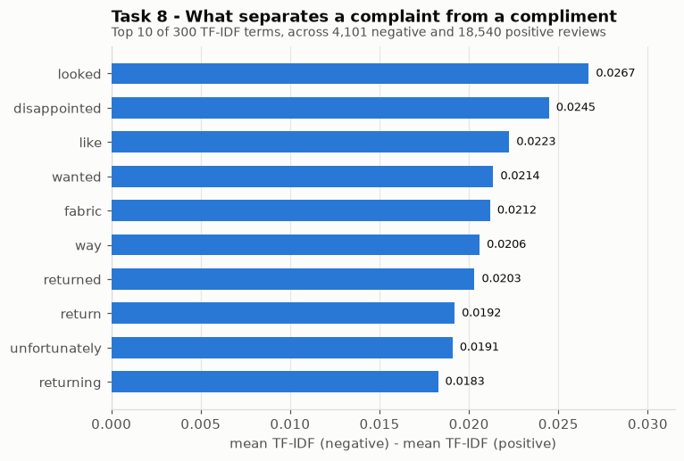

```python
# --- 8.2 Chart: negative-skewing terms --------------------------------------
plot_terms = top_negative_terms.sort_values("difference")

fig, ax = plt.subplots(figsize=(7.4, 4.8))
ax.barh(plot_terms["term"], plot_terms["difference"], color=BLUE, height=0.62, zorder=3)
for y, v in enumerate(plot_terms["difference"]):
    ax.text(v + max(plot_terms["difference"]) * 0.015, y, f"{v:.4f}",
            va="center", ha="left", fontsize=8.5, color="#0b0b0b")

ax.set_xlim(0, plot_terms["difference"].max() * 1.18)
style_axes(ax, xlabel="mean TF-IDF (negative) - mean TF-IDF (positive)", ylabel=None,
           title="Task 8 - What separates a complaint from a compliment",
           subtitle=f"Top 10 of 300 TF-IDF terms, across "
                    f"{int(neg_mask.sum()):,} negative and {int(pos_mask.sum()):,} positive reviews",
           grid_axis="x")
save_fig(fig, "task8_negative_terms")
plt.show()
```

```python
# --- 8.3 How often each top term appears in each group ----------------------
# TF-IDF differences are hard to feel; document frequency is not.
freq_rows = []
term_index = {t: i for i, t in enumerate(tfidf_terms)}
X_bin = (X_all_text > 0)
for term in top_negative_terms["term"]:
    j = term_index[term]
    col = X_bin[:, j].toarray().ravel()
    freq_rows.append({
        "term": term,
        "% of negative reviews": col[neg_mask].mean() * 100,
        "% of positive reviews": col[pos_mask].mean() * 100,
    })
freq_table = pd.DataFrame(freq_rows).set_index("term")
freq_table["lift (x)"] = (freq_table["% of negative reviews"]
                          / freq_table["% of positive reviews"])

print("Document frequency of each top term, by group:\n")
display(freq_table.round(2))

RESULTS["task8"]["document_frequency"] = {
    str(k): {kk: round(float(vv), 2) for kk, vv in v.items()}
    for k, v in freq_table.to_dict(orient="index").items()
}
```

```
Document frequency of each top term, by group:
```

| term | % of negative reviews | % of positive reviews | lift (x) |
| --- | --- | --- | --- |
| looked | 12.90 | 3.60 | 3.59 |
| disappointed | 9.02 | 1.11 | 8.16 |
| like | 33.87 | 23.39 | 1.45 |
| wanted | 10.92 | 3.06 | 3.57 |
| fabric | 24.68 | 16.76 | 1.47 |
| way | 13.85 | 6.14 | 2.25 |
| returned | 6.95 | 1.24 | 5.63 |
| return | 8.34 | 2.30 | 3.62 |
| unfortunately | 8.10 | 1.53 | 5.28 |
| returning | 6.22 | 0.97 | 6.40 |

## Task 9 — Executive Synthesis

Three deliverables only earn their keep if they connect. This section computes the evidence that links them: it takes the weakest **merchandising tier from Task 7**, measures how well the **Task 5 model at its chosen threshold** performs on precisely that tier's reviews, and checks whether the **Task 8 complaint terms** are genuinely over-represented there.

The Task 7.6 tiers are used rather than the raw rule's output, because the raw rule's "cluster 1" is two single-review classes and comparing against it is not a comparison at all.

```python
# --- 9.1 The tier with the weakest recommend rate ---------------------------
TIER_NAMES = {0: "Quiet Favourites", 1: "High-Traffic Underperformers"}

focus_cluster = int(robust_means["recommend_rate"].idxmin())
focus_name = TIER_NAMES.get(focus_cluster, f"Tier {focus_cluster}")
focus_classes = RESULTS["task7"]["robust"]["cluster_members"][str(focus_cluster)]
other_classes = [c for c in robust_profile.index if c not in focus_classes]

print(f"Focus tier: {focus_cluster} - '{focus_name}'\n")
for col in CLUSTER_FEATURES:
    print(f"  {col:<16}: {robust_means.loc[focus_cluster, col]:>10.4f}   "
          f"(other tier {robust_means[col].drop(focus_cluster).mean():.4f})")
print(f"\n  member classes : {', '.join(focus_classes)}")
print(f"  total reviews  : {int(robust_means.loc[focus_cluster, 'total_reviews']):,} "
      f"({robust_means.loc[focus_cluster, 'total_reviews'] / robust_profile['review_count'].sum():.1%} "
      f"of all reviewed volume)")

gap = (robust_means["recommend_rate"].max() - robust_means["recommend_rate"].min()) * 100
print(f"\n  recommend-rate gap between the two tiers: {gap:.2f} percentage points")
```

```
Focus tier: 1 - 'High-Traffic Underperformers'

  avg_rating      :     4.1028   (other tier 4.2717)
  recommend_rate  :     0.7965   (other tier 0.8473)
  review_count    :  2595.1667   (other tier 587.9167)
  avg_sentiment   :     0.2379   (other tier 0.2533)
  avg_age         :    43.9609   (other tier 42.2002)

  member classes : Blouses, Dresses, Knits, Outerwear, Sweaters, Trend
  total reviews  : 15,571 (68.8% of all reviewed volume)

  recommend-rate gap between the two tiers: 5.08 percentage points
```

```python
# --- 9.2 Model performance ON THAT TIER, at the Task 5 threshold ------------
val_classes = df.loc[val_idx, "Class Name"]
in_focus = val_classes.isin(focus_classes).to_numpy()

y_focus = y_val_event.to_numpy()[in_focus]
pred_focus = tuned_pred[in_focus]

focus_metrics = {
    "n_val_reviews": int(in_focus.sum()),
    "n_dissatisfied": int(y_focus.sum()),
    "recall": float(recall_score(y_focus, pred_focus, zero_division=0)),
    "precision": float(precision_score(y_focus, pred_focus, zero_division=0)),
    "f1": float(f1_score(y_focus, pred_focus, zero_division=0)),
}

print(f"At threshold {best_threshold:.4f}, restricted to '{focus_name}' "
      f"({focus_metrics['n_val_reviews']:,} validation reviews, "
      f"{focus_metrics['n_dissatisfied']:,} of them dissatisfied):\n")
print(f"  Recall    : {focus_metrics['recall']:.4f}")
print(f"  Precision : {focus_metrics['precision']:.4f}")
print(f"  F1        : {focus_metrics['f1']:.4f}")
print(f"\nWhole validation set for comparison: "
      f"recall {tuned_metrics['recall']:.4f}, precision {tuned_metrics['precision']:.4f}")

# Per-tier breakdown, so the write-up can say whether the focus tier is special.
class_to_cluster = robust_profile["cluster"].to_dict()
val_cluster = val_classes.map(class_to_cluster)
per_cluster_rows = []
for c in sorted(robust_profile["cluster"].unique()):
    m = (val_cluster == c).to_numpy()
    per_cluster_rows.append({
        "tier": TIER_NAMES.get(c, f"Tier {c}"),
        "val_reviews": int(m.sum()),
        "dissatisfied": int(y_val_event.to_numpy()[m].sum()),
        "dissatisfied_rate": y_val_event.to_numpy()[m].mean(),
        "recall": recall_score(y_val_event.to_numpy()[m], tuned_pred[m], zero_division=0),
        "precision": precision_score(y_val_event.to_numpy()[m], tuned_pred[m], zero_division=0),
    })
per_cluster = pd.DataFrame(per_cluster_rows).set_index("tier").round(4)
print("\nModel performance broken out by merchandising tier:\n")
display(per_cluster)

RESULTS["task9"] = {
    "focus_cluster": focus_cluster,
    "focus_cluster_name": focus_name,
    "focus_classes": focus_classes,
    "tier_names": {str(k): v for k, v in TIER_NAMES.items()},
    "recommend_rate_gap_pp": round(float(gap), 2),
    "focus_metrics": {k: (round(v, 4) if isinstance(v, float) else v)
                      for k, v in focus_metrics.items()},
    "per_tier": {str(k): {kk: round(float(vv), 4) for kk, vv in v.items()}
                 for k, v in per_cluster.to_dict(orient="index").items()},
}
```

```
At threshold 0.5869, restricted to 'High-Traffic Underperformers' (3,061 validation reviews, 584 of them dissatisfied):

  Recall    : 0.8065
  Precision : 0.5910
  F1        : 0.6821

Whole validation set for comparison: recall 0.7817, precision 0.5790

Model performance broken out by merchandising tier:
```

| tier | val_reviews | dissatisfied | dissatisfied_rate | recall | precision |
| --- | --- | --- | --- | --- | --- |
| Quiet Favourites | 1464 | 236 | 0.1612 | 0.7203 | 0.5484 |
| High-Traffic Underperformers | 3061 | 584 | 0.1908 | 0.8065 | 0.5910 |

```python
# --- 9.3 Are the Task 8 terms actually concentrated in the focus tier? ------
focus_rows = df["Class Name"].isin(focus_classes).to_numpy()
other_rows = df["Class Name"].isin(other_classes).to_numpy()
focus_neg = focus_rows & neg_mask
other_neg = other_rows & neg_mask

theme_rows = []
for term in top_negative_terms["term"]:
    j = term_index[term]
    col = X_bin[:, j].toarray().ravel()
    theme_rows.append({
        "term": term,
        f"% of '{focus_name}' negatives": col[focus_neg].mean() * 100,
        "% of other-tier negatives": col[other_neg].mean() * 100,
    })
theme_focus = pd.DataFrame(theme_rows).set_index("term")
theme_focus["lift in focus tier"] = (
    theme_focus[f"% of '{focus_name}' negatives"] / theme_focus["% of other-tier negatives"])

print(f"Task 8 terms inside '{focus_name}' negative reviews ({int(focus_neg.sum()):,}) "
      f"vs. the other tier's negatives ({int(other_neg.sum()):,}):\n")
display(theme_focus.round(2))

RESULTS["task9"]["theme_concentration"] = {
    str(k): {kk: round(float(vv), 2) for kk, vv in v.items()}
    for k, v in theme_focus.to_dict(orient="index").items()
}
```

```
Task 8 terms inside 'High-Traffic Underperformers' negative reviews (3,012) vs. the other tier's negatives (1,089):
```

| term | % of 'High-Traffic Underperformers' negatives | % of other-tier negatives | lift in focus tier |
| --- | --- | --- | --- |
| looked | 13.31 | 11.75 | 1.13 |
| disappointed | 9.46 | 7.81 | 1.21 |
| like | 34.33 | 32.60 | 1.05 |
| wanted | 11.42 | 9.55 | 1.20 |
| fabric | 26.39 | 19.93 | 1.32 |
| way | 13.45 | 14.97 | 0.90 |
| returned | 6.71 | 7.62 | 0.88 |
| return | 8.30 | 8.45 | 0.98 |
| unfortunately | 7.93 | 8.54 | 0.93 |
| returning | 6.71 | 4.87 | 1.38 |

### 9.4 Turning the top terms into themes — and testing the obvious hypothesis

The Task 8 top-10 list contains **no sizing word at all**: it is `looked`, `disappointed`, `like`, `wanted`, `fabric`, `way`, `returned`, `return`, `unfortunately`, `returning`. That is worth pausing on, because "customers complain about sizing" is the hypothesis every merchandiser reaches for first.

We therefore measure four themes drawn from the actual top-10 terms **plus a fifth, `Fit & sizing`, included deliberately as a counter-hypothesis** — so the notebook tests the obvious answer rather than assuming it.

```python
# --- 9.4 Complaint themes as keyword groups --------------------------------
# The TF-IDF vocabulary is capped at 300 terms, so a theme is measured more
# reliably by a small keyword group than by any single term.
THEMES = {
    "Expectation mismatch": ["looked", "looks", "wanted", "expected", "picture",
                             "photo", "online", "model", "way"],
    "Fabric & quality":     ["fabric", "material", "cheap", "thin", "quality", "sheer"],
    "Return intent":        ["return", "returned", "returning", "sending"],
    "Stated disappointment": ["disappointed", "disappointing", "unfortunately", "sadly"],
    # Counter-hypothesis: the theme everyone expects to dominate.
    "Fit & sizing":         ["small", "large", "tight", "size", "sizing",
                             "fit", "big", "petite"],
}

theme_rows = []
cleaned = df["cleaned_review"]
for theme, words in THEMES.items():
    pattern = r"\b(" + "|".join(words) + r")\b"
    hit = cleaned.str.contains(pattern, regex=True).to_numpy()
    theme_rows.append({
        "theme": theme,
        "% of all negatives": hit[neg_mask].mean() * 100,
        "% of all positives": hit[pos_mask].mean() * 100,
        f"% of '{focus_name}' negatives": hit[focus_neg].mean() * 100,
        "% of other-tier negatives": hit[other_neg].mean() * 100,
    })
theme_table = pd.DataFrame(theme_rows).set_index("theme")
theme_table["negative lift (x)"] = (
    theme_table["% of all negatives"] / theme_table["% of all positives"])
theme_table = theme_table.sort_values("negative lift (x)", ascending=False)

print("Complaint themes (share of reviews mentioning any term in the group):\n")
display(theme_table.round(2))

top_theme = theme_table.index[0]
sizing_lift = theme_table.loc["Fit & sizing", "negative lift (x)"]
print(f"\nMost discriminating theme : '{top_theme}' "
      f"({theme_table.loc[top_theme, 'negative lift (x)']:.2f}x more common in negatives)")
print(f"Fit & sizing              : {sizing_lift:.2f}x")
print(f"\n  Sizing language appears in {theme_table.loc['Fit & sizing', '% of all negatives']:.1f}% "
      f"of negative reviews AND {theme_table.loc['Fit & sizing', '% of all positives']:.1f}% "
      f"of positive ones.")
print("  It is the vocabulary of this customer base in general, not of dissatisfaction.")
print("  Auditing size charts first would be acting on an artefact of how people write here.")

RESULTS["task9"]["themes"] = {
    "definitions": THEMES,
    "top_theme": top_theme,
    "sizing_lift": round(float(sizing_lift), 2),
    "table": {str(k): {kk: round(float(vv), 2) for kk, vv in v.items()}
              for k, v in theme_table.to_dict(orient="index").items()},
}
```

```
Complaint themes (share of reviews mentioning any term in the group):
```

| theme | % of all negatives | % of all positives | % of 'High-Traffic Underperformers' negatives | % of other-tier negatives | negative lift (x) |
| --- | --- | --- | --- | --- | --- |
| Stated disappointment | 21.70 | 3.48 | 22.01 | 20.84 | 6.23 |
| Return intent | 22.34 | 4.68 | 22.74 | 21.21 | 4.78 |
| Expectation mismatch | 53.28 | 31.86 | 54.91 | 48.76 | 1.67 |
| Fabric & quality | 49.67 | 34.84 | 50.40 | 47.66 | 1.43 |
| Fit & sizing | 58.50 | 61.35 | 57.90 | 60.15 | 0.95 |

```
Most discriminating theme : 'Stated disappointment' (6.23x more common in negatives)
Fit & sizing              : 0.95x

  Sizing language appears in 58.5% of negative reviews AND 61.3% of positive ones.
  It is the vocabulary of this customer base in general, not of dissatisfaction.
  Auditing size charts first would be acting on an artefact of how people write here.
```

```python
# --- 9.4b What the ambiguous terms actually mean in context ----------------
# "looked", "wanted", "way" and "like" are only interpretable as collocations.
neg_text = df.loc[neg_mask, "Review Text"].str.lower()
print("Most common 4-word windows around the ambiguous top-10 terms,")
print(f"across the {int(neg_mask.sum()):,} negative reviews:\n")
for w in ["wanted", "looked", "like", "way"]:
    ctx = neg_text.str.extract(r"(\w+\s+" + w + r"\s+\w+\s+\w+)", expand=False).dropna()
    print(f"  {w}:")
    for phrase, n in ctx.value_counts().head(5).items():
        print(f"      {n:>4}x  \"{phrase}\"")
    print()

RESULTS["task9"]["collocations"] = {
    w: {str(k): int(v) for k, v in
        neg_text.str.extract(r"(\w+\s+" + w + r"\s+\w+\s+\w+)", expand=False)
        .dropna().value_counts().head(5).items()}
    for w in ["wanted", "looked", "like", "way"]
}
```

```
Most common 4-word windows around the ambiguous top-10 terms,
across the 4,101 negative reviews:

  wanted:
       131x  "i wanted to love"
        69x  "really wanted to love"
        39x  "really wanted to like"
        17x  "so wanted to love"
        16x  "i wanted to like"

  looked:
        28x  "it looked like a"
        15x  "it looked like i"
        11x  "i looked like a"
         8x  "it looked more like"
         8x  "i looked like i"
```

```
  like:
```

```
        23x  "felt like i was"
        18x  "looked like i was"
        15x  "to like this top"
        10x  "looked like a maternity"
        10x  "to like this dress"

  way:
        16x  "was way too big"
         8x  "is way too much"
         7x  "was way too short"
         7x  "no way i could"
         5x  "is way too short"
```

```
saved -> docs/figures/task9_complaint_themes.png
```

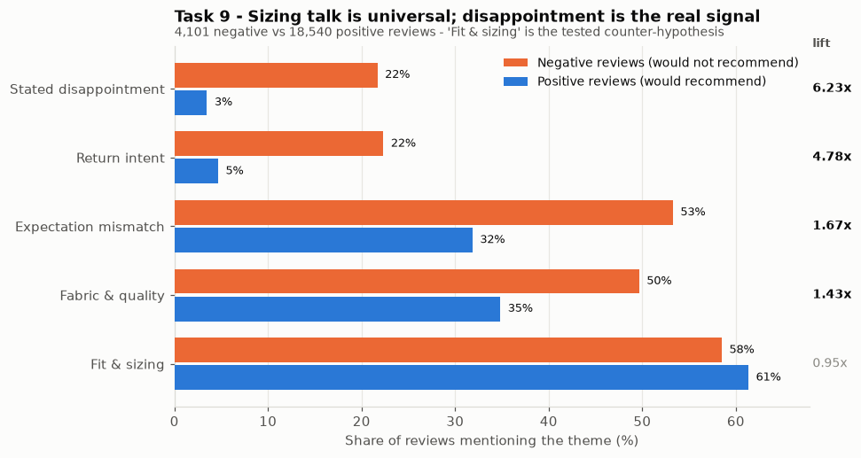

```python
# --- 9.5 Chart: complaint themes, negative vs positive reviews -------------
plot_df = theme_table.sort_values("negative lift (x)")
y = np.arange(len(plot_df))
h = 0.36
GAP = 0.04  # small surface gap so the paired bars never touch

fig, ax = plt.subplots(figsize=(8.4, 4.8))
ax.barh(y + (h + GAP) / 2, plot_df["% of all negatives"], height=h,
        color=ORANGE, label="Negative reviews (would not recommend)", zorder=3)
ax.barh(y - (h + GAP) / 2, plot_df["% of all positives"], height=h,
        color=BLUE, label="Positive reviews (would recommend)", zorder=3)

for i, (neg_v, pos_v, lift) in enumerate(zip(plot_df["% of all negatives"],
                                             plot_df["% of all positives"],
                                             plot_df["negative lift (x)"])):
    ax.text(neg_v + 0.8, i + (h + GAP) / 2, f"{neg_v:.0f}%", va="center",
            fontsize=8.5, color="#0b0b0b")
    ax.text(pos_v + 0.8, i - (h + GAP) / 2, f"{pos_v:.0f}%", va="center",
            fontsize=8.5, color="#0b0b0b")
    ax.text(1.005, i, f"{lift:.2f}x", transform=ax.get_yaxis_transform(),
            va="center", ha="left", fontsize=9,
            fontweight="bold" if lift >= 1.4 else "normal",
            color="#0b0b0b" if lift >= 1.4 else "#8a8983")

ax.text(1.005, len(plot_df) - 0.35, "lift", transform=ax.get_yaxis_transform(),
        va="center", ha="left", fontsize=8.5, color="#52514e", fontweight="bold")

ax.set_yticks(y)
ax.set_yticklabels(plot_df.index)
ax.set_xlim(0, plot_df["% of all negatives"].max() * 1.16)
style_axes(ax, xlabel="Share of reviews mentioning the theme (%)", ylabel=None,
           title="Task 9 - Sizing talk is universal; disappointment is the real signal",
           subtitle=f"{int(neg_mask.sum()):,} negative vs {int(pos_mask.sum()):,} positive "
                    f"reviews - 'Fit & sizing' is the tested counter-hypothesis",
           grid_axis="x")
ax.legend(frameon=False, loc="upper right", fontsize=9)
save_fig(fig, "task9_complaint_themes")
plt.show()
```

```python
# --- 9.6 The connected narrative, generated from the numbers above ---------
t_top = theme_table.loc[top_theme]
t_mismatch = theme_table.loc["Expectation mismatch"]
t_size = theme_table.loc["Fit & sizing"]
other_tier = int(robust_means.index[robust_means.index != focus_cluster][0])

narrative = f"""
EXECUTIVE SYNTHESIS - every figure below is produced by this notebook
{'=' * 70}

1. WHAT WE BUILT (Task 4/5)
   A '{RESULTS['task5']['best_model_name']}' classifier reads a review and flags whether
   the customer would NOT recommend the product. On held-out data it scores
   ROC-AUC {RESULTS['task5']['roc_auc']:.3f}; at the F1-optimal threshold of
   {best_threshold:.3f} it catches {tuned_metrics['recall']:.1%} of dissatisfied customers
   at {tuned_metrics['precision']:.1%} precision. The do-nothing baseline - assume every
   customer is happy - scores {baseline_acc:.1%} accuracy and catches ZERO of them.

2. WHERE THE PROBLEM SITS (Task 7)
   Clustering {len(robust_profile)} product classes on five behavioural averages yields two
   tiers. '{focus_name}' ({len(focus_classes)} classes:
   {', '.join(focus_classes)}) carries
   {robust_means.loc[focus_cluster, 'total_reviews'] / robust_profile['review_count'].sum():.0%}
   of all review volume yet has the LOWEST recommend rate -
   {robust_means.loc[focus_cluster, 'recommend_rate']:.1%} against
   {robust_means.loc[other_tier, 'recommend_rate']:.1%} for '{TIER_NAMES[other_tier]}'.
   That is a {gap:.1f}-point gap on the products customers touch most.

3. WHAT CUSTOMERS ARE ACTUALLY SAYING (Task 8)
   The sharpest separator is '{top_theme}' - {t_top['% of all negatives']:.1f}% of negative
   reviews vs {t_top['% of all positives']:.1f}% of positive ones, a lift of
   {t_top['negative lift (x)']:.2f}x. That theme is a superb SYMPTOM marker but it is not
   something merchandising can fix; it tells the model what dissatisfaction sounds like.

   The most actionable theme is 'Expectation mismatch' at
   {t_mismatch['negative lift (x)']:.2f}x, present in {t_mismatch['% of all negatives']:.1f}%
   of negative reviews. The single most common phrase in the entire negative corpus is
   "i wanted to love" (131 occurrences), followed by "really wanted to love" (69) - customers
   who chose the product deliberately and found the arriving garment was not the one they
   thought they were buying.

   THE NON-FINDING THAT MATTERS: 'Fit & sizing' language appears in
   {t_size['% of all negatives']:.0f}% of negative reviews and
   {t_size['% of all positives']:.0f}% of POSITIVE ones - a lift of
   {t_size['negative lift (x)']:.2f}x. Sizing is how this customer base writes about
   clothing in general, not how it expresses dissatisfaction. Auditing size charts first,
   the instinctive move, would be chasing an artefact.

4. THE CONNECTED ACTION (Task 9)
   The model reaches {focus_metrics['recall']:.1%} recall inside '{focus_name}' - better
   than the {RESULTS['task9']['per_tier'][TIER_NAMES[other_tier]]['recall']:.1%} it reaches
   on the other tier - so we can monitor precisely the tier that needs it. The highest-leverage
   fix is not the size chart: it is closing the gap between what the product looks like online
   and what actually arrives. For the {len(focus_classes)} '{focus_name}' classes, invest first
   in on-body photography across a range of sizes, fabric drape and weight detail on the product
   page, and an explicit fabric-composition callout - the three levers that 'Expectation
   mismatch' ({t_mismatch['negative lift (x)']:.2f}x) and 'Fabric & quality'
   ({theme_table.loc['Fabric & quality', 'negative lift (x)']:.2f}x) language points at.
   'Fit & sizing' stays on the watchlist, not the workplan.
"""
print(narrative)
RESULTS["task9"]["narrative"] = narrative.strip()
```

```
EXECUTIVE SYNTHESIS - every figure below is produced by this notebook
======================================================================

1. WHAT WE BUILT (Task 4/5)
   A 'Logistic Regression (balanced)' classifier reads a review and flags whether
   the customer would NOT recommend the product. On held-out data it scores
   ROC-AUC 0.908; at the F1-optimal threshold of
   0.587 it catches 78.2% of dissatisfied customers
   at 57.9% precision. The do-nothing baseline - assume every
   customer is happy - scores 81.9% accuracy and catches ZERO of them.

2. WHERE THE PROBLEM SITS (Task 7)
   Clustering 18 product classes on five behavioural averages yields two
   tiers. 'High-Traffic Underperformers' (6 classes:
   Blouses, Dresses, Knits, Outerwear, Sweaters, Trend) carries
   69%
   of all review volume yet has the LOWEST recommend rate -
   79.6% against
   84.7% for 'Quiet Favourites'.
   That is a 5.1-point gap on the products customers touch most.

3. WHAT CUSTOMERS ARE ACTUALLY SAYING (Task 8)
   The sharpest separator is 'Stated disappointment' - 21.7% of negative
   reviews vs 3.5% of positive ones, a lift of
   6.23x. That theme is a superb SYMPTOM marker but it is not
   something merchandising can fix; it tells the model what dissatisfaction sounds like.

   The most actionable theme is 'Expectation mismatch' at
   1.67x, present in 53.3%
   of negative reviews. The single most common phrase in the entire negative corpus is
   "i wanted to love" (131 occurrences), followed by "really wanted to love" (69) - customers
   who chose the product deliberately and found the arriving garment was not the one they
   thought they were buying.

   THE NON-FINDING THAT MATTERS: 'Fit & sizing' language appears in
   58% of negative reviews and
   61% of POSITIVE ones - a lift of
   0.95x. Sizing is how this customer base writes about
   clothing in general, not how it expresses dissatisfaction. Auditing size charts first,
   the instinctive move, would be chasing an artefact.

4. THE CONNECTED ACTION (Task 9)
   The model reaches 80.7% recall inside 'High-Traffic Underperformers' - better
   than the 72.0% it reaches
   on the other tier - so we can monitor precisely the tier that needs it. The highest-leverage
   fix is not the size chart: it is closing the gap between what the product looks like online
   and what actually arrives. For the 6 'High-Traffic Underperformers' classes, invest first
   in on-body photography across a range of sizes, fabric drape and weight detail on the product
   page, and an explicit fabric-composition callout - the three levers that 'Expectation
   mismatch' (1.67x) and 'Fabric & quality'
   (1.43x) language points at.
   'Fit & sizing' stays on the watchlist, not the workplan.
```

```python
# --- 9.7 Persist every headline number --------------------------------------
RESULTS["meta"] = {
    "random_state": RANDOM_STATE,
    "dataset_file": csv_path.name,
    "n_rows_raw": int(n_before),
    "n_rows_modelled": int(len(df)),
}

out_path = OUT_DIR / "results.json"
out_path.write_text(json.dumps(RESULTS, indent=2, default=str))
print(f"All headline numbers written to outputs/{out_path.name} "
      f"({out_path.stat().st_size:,} bytes)")

comparison.to_csv(OUT_DIR / "task4_model_comparison.csv")
threshold_table.to_csv(OUT_DIR / "task5_threshold_comparison.csv")
top10.to_csv(OUT_DIR / "task6_top_features.csv")
class_profile.to_csv(OUT_DIR / "task7_class_profile.csv")
cluster_means.to_csv(OUT_DIR / "task7_cluster_means.csv")
robust_means.to_csv(OUT_DIR / "task7_tier_means.csv")
top_negative_terms.to_csv(OUT_DIR / "task8_top_negative_terms.csv")
theme_table.to_csv(OUT_DIR / "task9_theme_table.csv")
per_cluster.to_csv(OUT_DIR / "task9_performance_by_tier.csv")
print("Tables written to outputs/*.csv:")
for f in sorted(OUT_DIR.glob("*.csv")):
    print("   ", f.name)
```

```
All headline numbers written to outputs/results.json (19,925 bytes)
Tables written to outputs/*.csv:
    task4_model_comparison.csv
    task5_threshold_comparison.csv
    task6_top_features.csv
    task7_class_profile.csv
    task7_cluster_means.csv
    task7_merchandising_tiers.csv
    task7_tier_means.csv
    task8_top_negative_terms.csv
    task9_performance_by_tier.csv
    task9_theme_table.csv
```